# 10 - Multifactorial design

John Shorter

Mar/05/2026

# Introduction

Last time we talked about randomized block design, and how one can using blocks to control for unintended variations in an experiment.

This time we are going to talk about multifactorial design. We will cover

1. What is a multifactorial design?
2. Why would one design a multifactorial experiment?
3. What is interaction between factors?
4. How to analyze a multifactorial experiment?

# Load packagess

```r
library(emmeans)
library(multcomp)
```

```r
library(multcompView)
library(ggplot2)
library(tidyr)
library(dplyr)
library(readr)
library(readxl)
library(RColorBrewer)
library(viridis)
```

# What is a multifactorial design?

A multifactorial design is an experiment that have multiple factors of independent variables. It might seem a bit abstract. So let’s see an actual example.

We will use the R built-in dataset ToothGrowth as an example. ToothGrowth is an experiment in which researchers looked at the effect of two supplements “VC” and “OJ” on the tooth length of guinea pigs.

Each animal was given a supplement (either OJ or VC); and the animal can receive a high dose (2), mid dose (1) or low dose (0.5). At the end of the experiment, the longest tooth of the animal is measured. Ref: Crampton, E. W. (1947). The Journal of Nutrition, 33(5), 491–504. doi: 10.1093/jn/33.5.491.

```r
head(ToothGrowth)
```

```
##    len supp dose
## 1  4.2   VC  0.5
## 2 11.5   VC  0.5
## 3  7.3   VC  0.5
## 4  5.8   VC  0.5
## 5  6.4   VC  0.5
## 6 10.0   VC  0.5
```

```r
str(ToothGrowth)
```

```
## 'data.frame':    60 obs. of  3 variables:
##  $ len : num  4.2 11.5 7.3 5.8 6.4 10 11.2 11.2 5.2 7 ...
##  $ supp: Factor w/ 2 levels "OJ","VC": 2 2 2 2 2 2 2 2 2 2 ...
##  $ dose: num  0.5 0.5 0.5 0.5 0.5 0.5 0.5 0.5 0.5 0.5 ...
```

Looks like it has 60 rows and 3 columns. “len” is tooth length. It will be our dependent variable. There are 2 kinds of “supp”: “VC” or “OJ”. And there are multiple levels of dose, which is recorded as a numeric variable in the table.

This experiment is called a multifactorial design because it has two independent variables of interest: supp and dose.

supp is a factor; dose is another factor. We have two factors of interest, thus multifactorial.

# Why would one want to do a multifactorial experiment?

The multifactorial design is popular because it is efficient. When we have multiple independent variables of interest, it allows us to compare multiple combinations of independent variables in the same time.

Let’s use the ToothGrowth data as an example. There are two supplements and three doses of each. 2 * 3 = 6 combinations. And the multifactorial design will allow us to compare all 6 combinations in the same time.

# What is interaction among factors?

A very important concept of the multifactorial design is interaction. Interaction stands for “the effect of one factor depends on the other factor”.

To understand this, let’s visualize the data first.

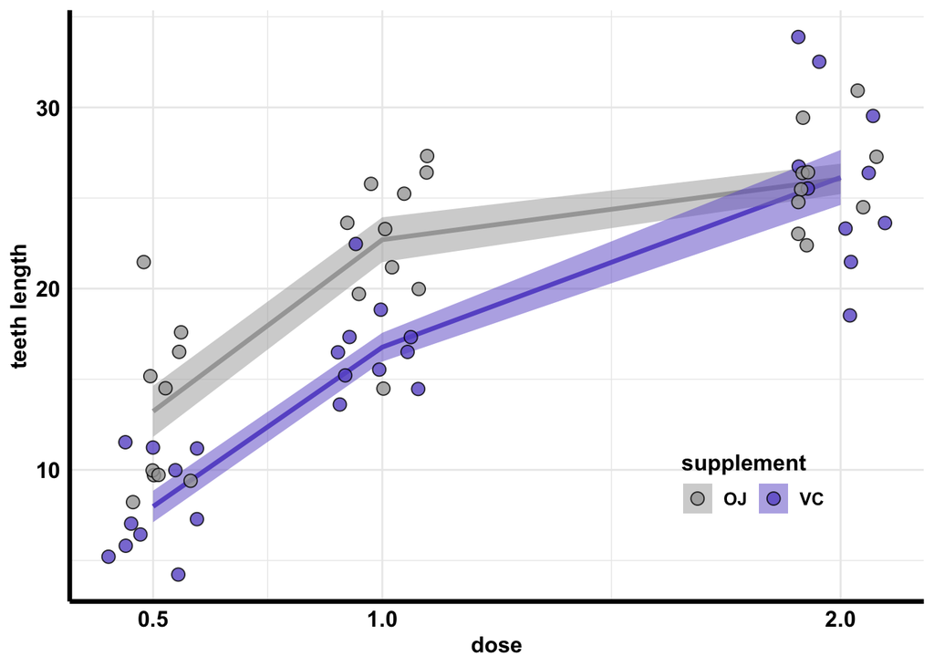

```r
wisteria <- c("grey65", "burlywood3", "khaki2", "plum1", "lightcyan2", "cornflowerblue", "slateblue3")

ToothGrowth %>%
  ggplot(aes(x = dose, y = len)) +
  stat_summary(geom = "line",
               fun = mean,
               aes(group = supp, color = supp),
               size = 1.2) +
  stat_summary(geom = "ribbon",
               fun.data = mean_se,
               aes(group = supp,
                   fill = supp),
               alpha = 0.5) +
  geom_point(aes(fill = supp),
             position = position_jitter(0.1, seed = 666),
             alpha = 0.8,
             size = 3,
             shape = 21,
             color = "black") +
  scale_fill_manual(values = wisteria[c(1, 7)]) +
  scale_color_manual(values = wisteria[c(1, 7)]) +
  scale_x_continuous(breaks = c(0.5, 1, 2)) +
  labs(x = "dose",
       y = "teeth length",
       fill = "supplement",
       color = "supplement") +
  guides(color = "none") +
  guides(fill = guide_legend(nrow = 1, ncol = 2)) + # set fill legend to 1 row 2 columns.
  theme_minimal() +
  theme(legend.position = c(0.8, 0.2),
        axis.line = element_line(size = 1.2),
        text = element_text(size = 12, color = "black", face = "bold"),
        axis.text = element_text(size = 12, color = "black", face = "bold")
        )
```

You can see that, as the dose of either supplement increases, the teeth length also increases. So for both supplements, higher dose = longer teeth.

But if you look carefully at the lines, you will notice that the two curves are not exactly parallel. While teeth are longer for OJ than VC in lower doses, there is no difference in dose = 2.

And **THAT** is interaction. The effect of supplement depends on the dose. The effect of one factor (supplement) depends on the other factor (dose). That’s interaction. In the graphical sense, it means the trends are not all parallel to each other.

When you set up a multifactorial design, you will most certainly encounter interactions.

# How to analyze a multifactorial experiment?

You will analyze a multifactorial experiment like a randomized block experiment, except that you will have to consider interaction now.

Let’s fill out the table.

| source | factor | levels |
| --- | --- | --- |
| supp | treat | 2 |
| dose | treat | 3 |
| animal | OU, EU | 60 |

We have supp and dose as our treatments. They have 2 and 3 levels, respectively. We have 60 observations of animal (each dot on the graph is an animal). In this case the animal is both observational units and experimental units.

Last time we learned that we should include all sources of variation except OU. So that gives `len ~ supp + dose`.

But how do I include the interaction between supp and dose in my linear model?

## Setting up linear model for multifactorial design

To include an interaction in a linear model, you use the `factor1:factor2` syntax.

That is `len ~ supp + dose + supp:dose`

There is a different syntax that you may also see for interactions. A simplified syntax is `len ~ supp * dose`. The `*` symbol means `+ and interaction`, that is `supp * dose` = `supp + dose + supp:dose`

Oftentimes people refer to the independent variables as the “main effects”. So supp and dose are your main effects.

When you set up your model, you type in the main effects first, then the interactions.

*WARNING*: the dose is recorded as a numeric variable in the dataset. In a multifactorial experiment, we need to set it as factor.

```r
ToothGrowth_new <- ToothGrowth %>%
  mutate(dose.f = as.factor(dose))
```

We can pull out the summary statistics first: In this case we will group by both supp and dose.f, the two factors.

```r
ToothGrowth_new %>%
  group_by(supp, dose.f) %>%
  summarise(mean = mean(len),
            var = var(len),
            sd = sd(len),
            n = n())
```

```
## # A tibble: 6 × 6
## # Groups:   supp [2]
##   supp  dose.f  mean   var    sd     n
##   <fct> <fct>  <dbl> <dbl> <dbl> <int>
## 1 OJ    0.5    13.2  19.9   4.46    10
## 2 OJ    1      22.7  15.3   3.91    10
## 3 OJ    2      26.1   7.05  2.66    10
## 4 VC    0.5     7.98  7.54  2.75    10
## 5 VC    1      16.8   6.33  2.52    10
## 6 VC    2      26.1  23.0   4.80    10
```

Well, the variances are not ideal, as not all of them are within a two-fold range, but all of them are at least within an order of magnitude. So maybe it’ll be okay.

```r
model_teeth <- lm(len ~ supp + dose.f + supp:dose.f, data = ToothGrowth_new)
```

You can also do `len ~ supp * dose.f`. That gives you the same thing.

Note that you can also set it up as `len ~ dose.f * supp`. Technically there is a minute difference between the two models, but oftentimes it makes no difference to your conclusions at the end of the day. We will ignore that technicality for now.

Let’s check the assumptions of ANOVA first. Normality?

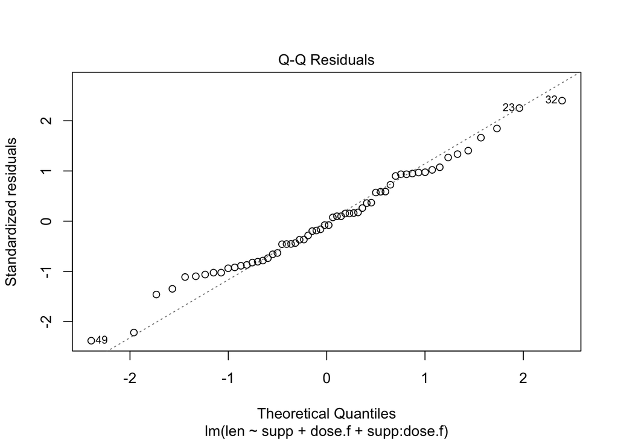

```r
plot(model_teeth, which = 2)
```

Pretty good!

Next, equal variance?

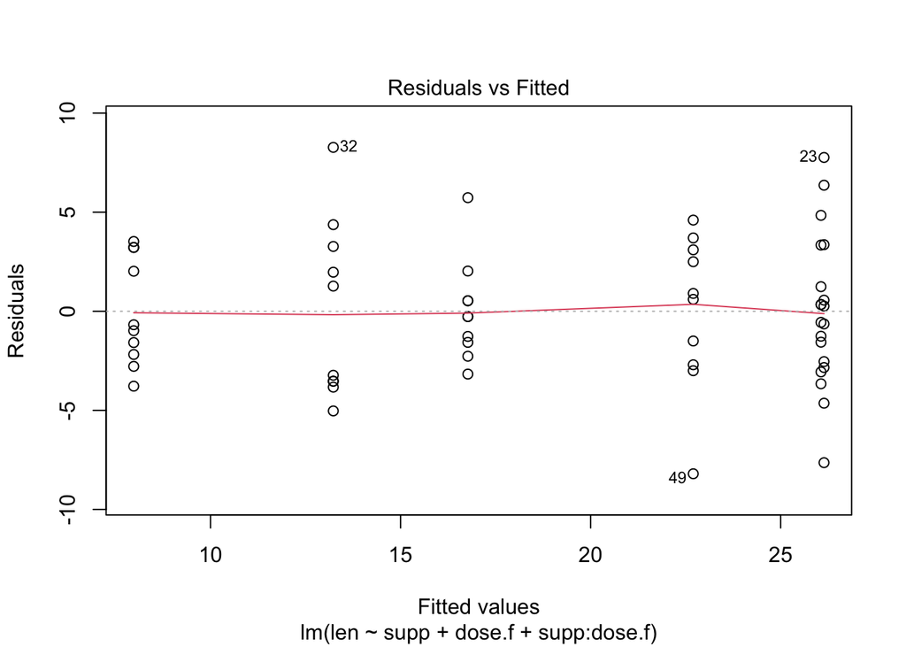

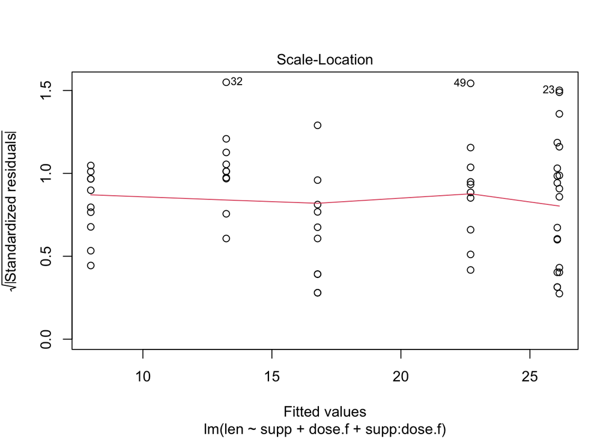

```r
plot(model_teeth, which = c(1, 3))
```

Looks rather okay to me. We are all clear to do ANOVA

## ANOVA

```r
anova(model_teeth)
```

```
## Analysis of Variance Table
##
## Response: len
##             Df  Sum Sq Mean Sq F value    Pr(>F)
## supp         1  205.35  205.35  15.572 0.0002312 ***
## dose.f       2 2426.43 1213.22  92.000 < 2.2e-16 ***
## supp:dose.f  2  108.32   54.16   4.107 0.0218603 *
## Residuals   54  712.11   13.19
## ---
## Signif. codes:  0 '***' 0.001 '**' 0.01 '*' 0.05 '.' 0.1 ' ' 1
```

1. supp has a F >> 1. That means the means of supp are different
2. dose.f has F >> 1 but also larger than the F value of supp. This means not only are the means of dose.f different, but also dose.f explain a larger proportion of variation in the data than supp.
3. Lastly, the interaction supp:dose.f has an F value significantly > 1 (p = 0.02 < 0.05). This means the effect of supp depends on the dose, consistent with what the graph showed us.

Now we can go ahead and find out which supp:dose combination gave us the longest teeth.

## Tukey tests

When you do a Tukey test on a multifactorial experiment, You need to be VERY THOUGHTFUL. Ask yourself what is the comparison that I am actually interested in?

In this example: Am I interested in the effect of supp at each dose level? Am I interested in the effect of dose for each supp?

Depending on the question of interest, you will need a different Tukey test layout. Of course the choice of analysis all depends on the researcher and their interests.

### Test effect of supp at each dose level

Let’s say we are interested in the effect of supp at each dose level. To specify that in the `emmeans()` command, we will use the `~ supp | dose` syntax. This means compare across supp at each dose level.

```r
estimate_per_dose <- emmeans(model_teeth,pairwise ~ supp | dose.f)
estimate_per_dose$contrast
```

```
## dose.f = 0.5:
##  contrast estimate   SE df t.ratio p.value
##  OJ - VC      5.25 1.62 54   3.233  0.0021
##
## dose.f = 1:
##  contrast estimate   SE df t.ratio p.value
##  OJ - VC      5.93 1.62 54   3.651  0.0006
##
## dose.f = 2:
##  contrast estimate   SE df t.ratio p.value
##  OJ - VC     -0.08 1.62 54  -0.049  0.9609
```

You can also pull out the cld

```r
cld(estimate_per_dose$emmeans, Letters = letters)
```

```
## dose.f = 0.5:
##  supp emmean   SE df lower.CL upper.CL .group
##  VC     7.98 1.15 54     5.68     10.3  a
##  OJ    13.23 1.15 54    10.93     15.5   b
##
## dose.f = 1:
##  supp emmean   SE df lower.CL upper.CL .group
##  VC    16.77 1.15 54    14.47     19.1  a
##  OJ    22.70 1.15 54    20.40     25.0   b
##
## dose.f = 2:
##  supp emmean   SE df lower.CL upper.CL .group
##  OJ    26.06 1.15 54    23.76     28.4  a
##  VC    26.14 1.15 54    23.84     28.4  a
##
## Confidence level used: 0.95
## significance level used: alpha = 0.05
## NOTE: If two or more means share the same grouping symbol,
##       then we cannot show them to be different.
##       But we also did not show them to be the same.
```

This tells us that at dose = 0.5 or 1, OJ gives longer teeth than VC. However, at dose = 2, OJ and VC have about the same effect.

### Test effect of dose at each supp

Now let’s say we are interested in the effect of different doses for each supp. How should we set up the `emmeans()` command?

You’ll use `~ dose.f | supp` now. This means compare across dose at each supp level.

```r
estimate_per_supp <- emmeans(model_teeth,pairwise ~ dose.f | supp)
estimate_per_supp$contrast
```

```
## supp = OJ:
##  contrast            estimate   SE df t.ratio p.value
##  dose.f0.5 - dose.f1    -9.47 1.62 54  -5.831 <0.0001
##  dose.f0.5 - dose.f2   -12.83 1.62 54  -7.900 <0.0001
##  dose.f1 - dose.f2      -3.36 1.62 54  -2.069  0.1060
##
## supp = VC:
##  contrast            estimate   SE df t.ratio p.value
##  dose.f0.5 - dose.f1    -8.79 1.62 54  -5.413 <0.0001
##  dose.f0.5 - dose.f2   -18.16 1.62 54 -11.182 <0.0001
##  dose.f1 - dose.f2      -9.37 1.62 54  -5.770 <0.0001
##
## P value adjustment: tukey method for comparing a family of 3 estimates
```

You can also pull up the cld

```r
cld(estimate_per_supp$emmeans, Letters = letters)
```

```
## supp = OJ:
##  dose.f emmean   SE df lower.CL upper.CL .group
##  0.5     13.23 1.15 54    10.93     15.5  a
##  1       22.70 1.15 54    20.40     25.0   b
##  2       26.06 1.15 54    23.76     28.4   b
##
## supp = VC:
##  dose.f emmean   SE df lower.CL upper.CL .group
##  0.5      7.98 1.15 54     5.68     10.3  a
##  1       16.77 1.15 54    14.47     19.1   b
##  2       26.14 1.15 54    23.84     28.4    c
##
## Confidence level used: 0.95
## P value adjustment: tukey method for comparing a family of 3 estimates
## significance level used: alpha = 0.05
## NOTE: If two or more means share the same grouping symbol,
##       then we cannot show them to be different.
##       But we also did not show them to be the same.
```

This tells us that

1. For OJ, dose 0.5 is significantly lower than dose 1 and 2. Dose 2 is not significantly different from dose 1.
2. For VC, as the dose increases, each dose is significantly different from the previous.

Hopefully you can see that depending on how we set up the emmeans command, we get different inferences. So before you set up a Tukey test for a multifactorial experiment, do think about what you are actually interested in.

# Exercise

Now you have learned how to analyze multifactorial experiment. You will practice it.

We will use an actual experiment “potato yield” as example. In this experiment, we are looking at the yield of two varieties of potato across different nitrogen input.

Potato from one of the two varieties were randomly assigned one of the 5 nitrogen treatments. At the end of the experiment, potatoes were harvested and weighed. (Data from UC Davis Plant Sciences course PLS205, Winter 2017)

```r
Potato_Yield <- read.csv("https://raw.githubusercontent.com/johnshorter/TeachingData/main/Potato_yield.csv")
head(Potato_Yield)
```

```
##   Nitrogen        Variety    Yield
## 1        0 Russet Burbank 397.6773
## 2       90 Russet Burbank 504.1822
## 3      150 Russet Burbank 501.2186
## 4      210 Russet Burbank 594.7640
## 5      270 Russet Burbank 607.4754
## 6        0  Alpine Russet 296.9766
```

```r
str(Potato_Yield)
```

```
## 'data.frame':    100 obs. of  3 variables:
##  $ Nitrogen: int  0 90 150 210 270 0 90 150 210 270 ...
##  $ Variety : chr  "Russet Burbank" "Russet Burbank" "Russet Burbank" "Russet Burbank" ...
##  $ Yield   : num  398 504 501 595 607 ...
```

## Visualize the data

Make the best plot you can to visualize the data.

What to put on x axis? What to color/fill with? Any faceting that you want to use?

WARNING: are there any numerically recorded variables you want to change into factors? (Hint: there is 1 variable that you need to change into factor.)

Make your plot here:

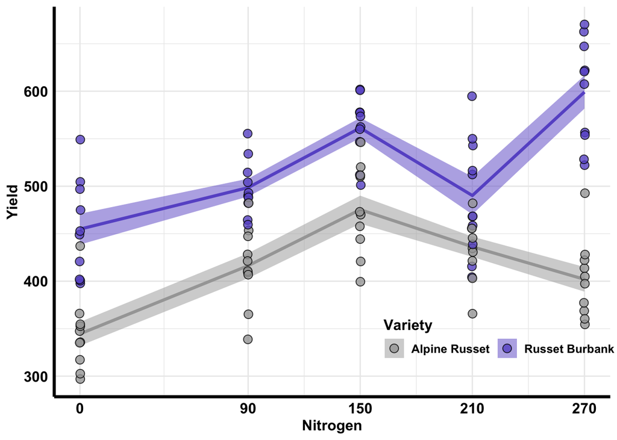

```r
wisteria <- c("grey65", "burlywood3", "khaki2", "plum1", "lightcyan2", "cornflowerblue", "slateblue3")

Potato_Yield %>%
  ggplot(aes(x = Nitrogen, y = Yield)) +
  stat_summary(geom = "line",
               fun = mean,
               aes(group = Variety, color = Variety),
               size = 1.2) +
  stat_summary(geom = "ribbon",
               fun.data = mean_se,
               aes(group = Variety,
                   fill = Variety),
               alpha = 0.5) +
  geom_point(aes(fill = Variety),
             position = position_jitter(0.3, seed = 666),
             alpha = 0.8,
             size = 3,
             shape = 21,
             color = "black") +
  scale_fill_manual(values = wisteria[c(1, 7)]) +
  scale_color_manual(values = wisteria[c(1, 7)]) +
  scale_x_continuous(breaks = c(0, 90, 150, 210, 270)) +
  labs(x = "Nitrogen",
       y = "Yield",
       fill = "Variety",
       color = "Variety") +
  guides(color = "none") +
  guides(fill = guide_legend(nrow = 1, ncol = 2)) + # set fill legend to 1 row 2 columns.
  theme_minimal() +
  theme(legend.position = c(0.8, 0.15),
        axis.line = element_line(size = 1.2),
        text = element_text(size = 12, color = "black", face = "bold"),
        axis.text = element_text(size = 12, color = "black", face = "bold")
        )
```

## Setting up the model

Fill out the table:

What are the sources of variation? What factors are they? (treatment? block? observational units? experimental units?) How many levels in each?

[output not shown]

What main effects should you include in the model? Which interactions should you include in the model?

Set up the linear model.

```r
potato <- Potato_Yield %>% mutate(Nitrogen = as.factor(Nitrogen))
potato %>% group_by(Nitrogen, Variety) %>% summarize(mean=mean(Yield), var=var(Yield), n = n())
```

```
## # A tibble: 10 × 5
## # Groups:   Nitrogen [5]
##    Nitrogen Variety         mean   var     n
##    <fct>    <chr>          <dbl> <dbl> <int>
##  1 0        Alpine Russet   345. 1568.    10
##  2 0        Russet Burbank  455. 2639.    10
##  3 90       Alpine Russet   416. 1737.    10
##  4 90       Russet Burbank  499.  883.    10
##  5 150      Alpine Russet   475. 2175.    10
##  6 150      Russet Burbank  561. 1130.    10
##  7 210      Alpine Russet   436. 1140.    10
##  8 210      Russet Burbank  490. 3949.    10
##  9 270      Alpine Russet   402. 1686.    10
## 10 270      Russet Burbank  599. 3031.    10
```

```r
model_yield <- lm(Yield ~ Nitrogen + Variety + Nitrogen:Variety, data = potato)
```

## check assumptions of ANOVA

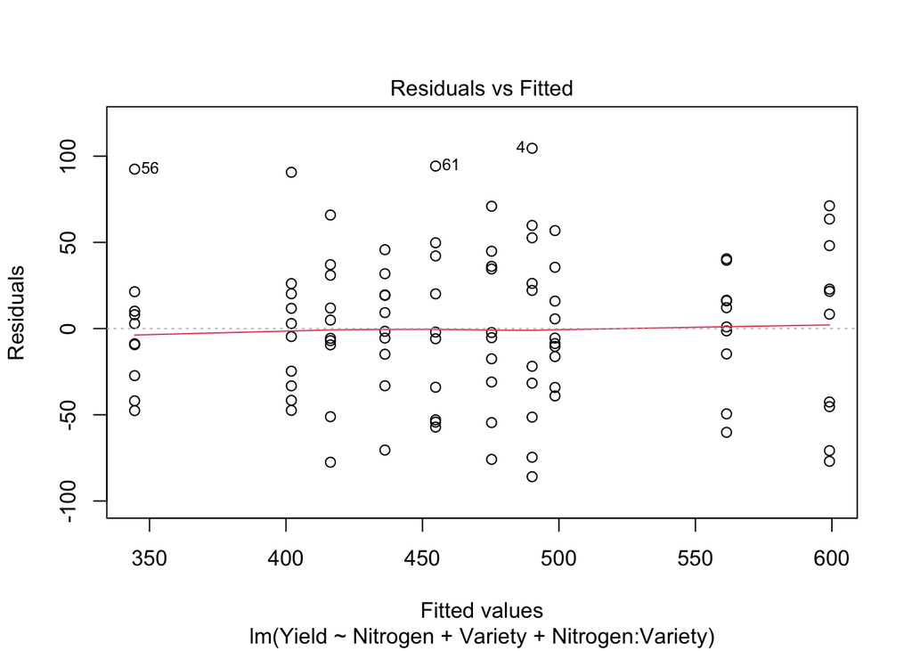

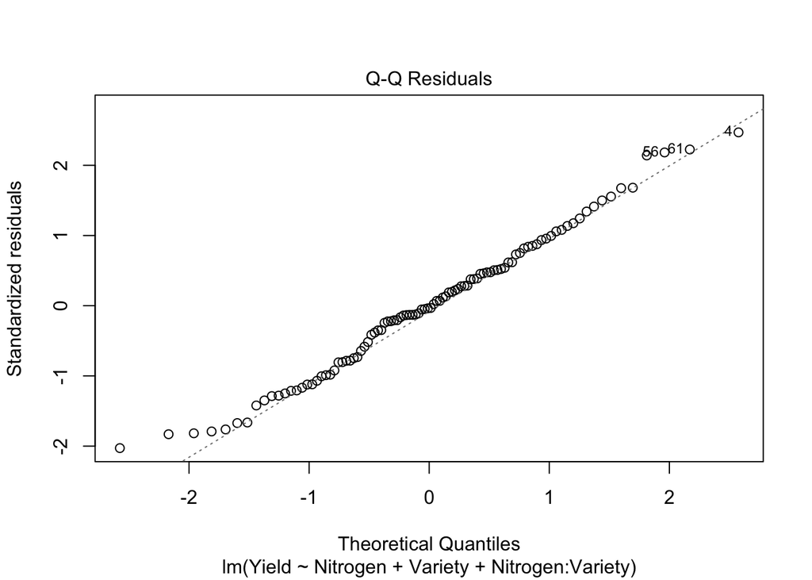

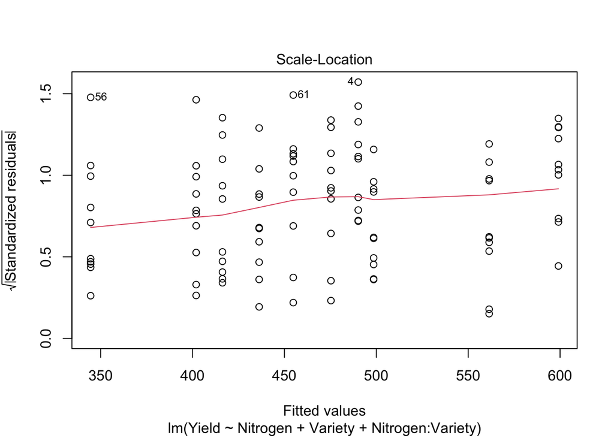

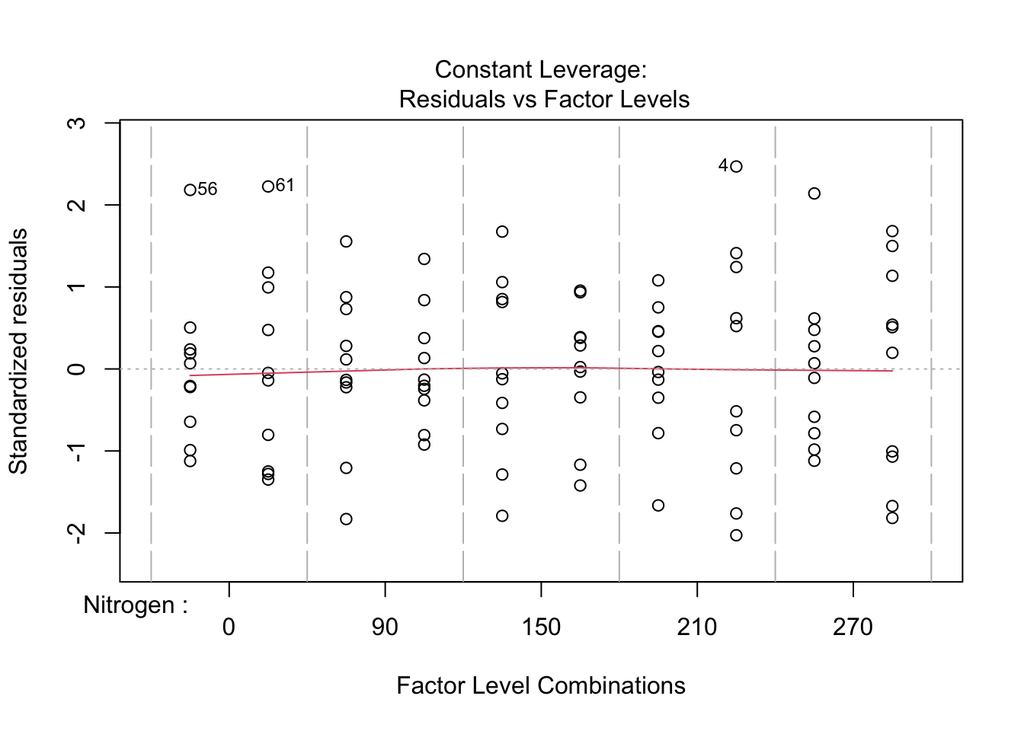

```r
plot(model_yield)
```

Normality?

Equal variance?

Residuals vs fitted looks quite good, showing linearity among the values. QQ plot of residuals also looks good. Scale location has a bit of a slope so we’re not quite homoskedastic. Higher values of Nitrogen tend to lead to higher variance. It’s not extreme though.

## Run ANOVA

How would you interpret the ANOVA table?

```r
anova(model_yield)
```

```
## Analysis of Variance Table
##
## Response: Yield
##                  Df Sum Sq Mean Sq  F value    Pr(>F)
## Nitrogen          4 167984   41996  21.0617 2.790e-12 ***
## Variety           1 280604  280604 140.7279 < 2.2e-16 ***
## Nitrogen:Variety  4  60001   15000   7.5229 2.831e-05 ***
## Residuals        90 179456    1994
## ---
## Signif. codes:  0 '***' 0.001 '**' 0.01 '*' 0.05 '.' 0.1 ' ' 1
```

Say we are interested in knowing which variety performs better in each nitrogen input. How should you set up the Tukey test?

```r
estimate_per_nitrogen <- emmeans(model_yield, pairwise ~ Variety|Nitrogen)
estimate_per_nitrogen$contrast
```

```
## Nitrogen = 0:
##  contrast                       estimate SE df t.ratio p.value
##  Alpine Russet - Russet Burbank   -110.3 20 90  -5.522 <0.0001
##
## Nitrogen = 90:
##  contrast                       estimate SE df t.ratio p.value
##  Alpine Russet - Russet Burbank    -82.3 20 90  -4.120 <0.0001
##
## Nitrogen = 150:
##  contrast                       estimate SE df t.ratio p.value
##  Alpine Russet - Russet Burbank    -86.1 20 90  -4.311 <0.0001
##
## Nitrogen = 210:
##  contrast                       estimate SE df t.ratio p.value
##  Alpine Russet - Russet Burbank    -53.9 20 90  -2.701  0.0083
##
## Nitrogen = 270:
##  contrast                       estimate SE df t.ratio p.value
##  Alpine Russet - Russet Burbank   -197.2 20 90  -9.873 <0.0001
```

Pull out the cld output and interpret the results.

```r
cld(estimate_per_nitrogen, Letters=letters)
```

```
## Nitrogen = 0:
##  Variety        emmean   SE df lower.CL upper.CL .group
##  Alpine Russet     345 14.1 90      316      373  a
##  Russet Burbank    455 14.1 90      427      483   b
##
## Nitrogen = 90:
##  Variety        emmean   SE df lower.CL upper.CL .group
##  Alpine Russet     416 14.1 90      388      444  a
##  Russet Burbank    499 14.1 90      471      527   b
##
## Nitrogen = 150:
##  Variety        emmean   SE df lower.CL upper.CL .group
##  Alpine Russet     475 14.1 90      447      503  a
##  Russet Burbank    561 14.1 90      533      589   b
##
## Nitrogen = 210:
##  Variety        emmean   SE df lower.CL upper.CL .group
##  Alpine Russet     436 14.1 90      408      464  a
##  Russet Burbank    490 14.1 90      462      518   b
##
## Nitrogen = 270:
##  Variety        emmean   SE df lower.CL upper.CL .group
##  Alpine Russet     402 14.1 90      374      430  a
##  Russet Burbank    599 14.1 90      571      627   b
##
## Confidence level used: 0.95
## significance level used: alpha = 0.05
## NOTE: If two or more means share the same grouping symbol,
##       then we cannot show them to be different.
##       But we also did not show them to be the same.
```

It shows that at each level of Nitrogen, the different Varieties have different means.

## What to submit to Moodle (Pass/Fail)

For this lesson, complete the exercises **in your shared Exercise Pack** (the file `Exercise_Pack_Template.Rmd`). Then **Knit to HTML** and upload the HTML file to the Moodle exercise folder.

**File name format:** `Lastname_Firstname_L10.html`

### Satisfactory / Not satisfactory (what I check)

Your submission is **Satisfactory** if:

- It **knits** (HTML opens and shows your work).
- You included **outputs** (plots/tables/model output) that match the lesson.
- You answered the **Self-check checklist** (short, honest, and complete).
- Your work is **plausible** (right method for the lesson, correct variables, no obvious copy/paste without results).

### Exercise 2 — Two-way model (main effects)

Fit a model with two predictors (factors) and report main effects.

**Self-check:** model includes both factors; you interpret at least one coefficient or ANOVA term.

### Exercise 3 — Interaction

Fit an interaction model and decide whether interaction is meaningful. Make an interaction plot.

**Self-check:** you state whether interaction is present and back it with output + plot.

### Exercise 4 — Simple effects / follow-up

If interaction exists (or even if weak), do one follow-up comparison (e.g., compare groups within one level).

**Self-check:** you explain what comparison you ran and why.

### Exercise 5 — Report-ready summary

Write a short “Results” paragraph (5–7 lines) that mentions main effects and interaction (if present).

**Self-check:** paragraph is readable and avoids overclaiming.